# Actividad 12 Funciones lambda y de orden superior

- Jorge Emiliano Pomar
- A01709338
- 25 de febrero de 2025

## Ejercicio 1

- La función lambda sector cuyos argumentos son el radio y el angulo. Utiliza la constante math.pi de la librería math.

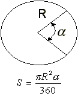

```python
import math as m
sector = lambda r, a : (m.pi * r**2 * a) / 360

def main():
    r = float(input("Ingresa el radio: "))
    a = float(input("Ingresa el ángulo: "))
    sec = sector(r, a)
    print("Sector: %.2f" % sec)


main()
```

```
Sector: 9.82
```

## Ejercicio 2

- La función lambda eclipse cuyos argumentos son los radios a y b. Utiliza la constante math.pi de la librería math.

```python
eclipse = lambda a, b: m.pi * a * b

def main():
    a = float(input("Ingresa el a: "))
    b = float(input("Ingresa el b: "))
    e = eclipse(a, b)
    print("Eclipse: %.2f" % e)

main()
```

```
Eclipse: 31.42
```

## Ejercicio 3

- La función lambda paralelogramo cuyos argumentos son la longitud a y la altura h.

```python
paralelogramo = lambda a, h: a * h

def main():
    a = float(input("Ingresa el a: "))
    h = float(input("Ingresa el h: "))
    p = paralelogramo(a, h)
    print("Paralelogramo: %.2f" % p)

main()
```

```
Paralelogramo: 33.12
```

## Ejercicio 4

- Definir una función de orden superior llamada operar, que recibe como parámetro dos enteros y una función. En el cuerpo de la función llamar a la función que llega como parámetro y enviar los dos primeros parámetros. La función retorna un entero.
- Definir la función multiplicar, que reciba dos números como parámetro de entrada: n1 y n2 y regrese la multiplicación de los números.
- Definir la función dividir, que reciba dos números como parámetro de entrada: n1 y n2 y regrese la división de n1 entre n2.
- En el script principal de nuestro programa:
- Llama a la función operar y le pasamos tres datos, dos enteros y uno con la referencia de la función multiplicar. Imprime el resultado.
- Llama a la función operar y le pasamos tres datos, dos enteros y uno con la referencia de la función dividir. Imprime el resultado.

```python
def operar(a, b, funcion):
    res = funcion(a, b)
    return res

multiplicar = lambda n1, n2: n1 * n2
dividir = lambda n1, n2: n1 / n2


def main():
    num1 = float(input("Ingresa el primer número: "))
    num2 = float(input("Ingresa el segundo número: "))
    resultado = operar(num1, num2, multiplicar)
    print("Multiplicacion: ", resultado)
    resultado = operar(num1, num2, dividir)
    print("Division: ", resultado)

main()
```

```
Multiplicacion:  2192.09
Division:  4.408071748878924
```